# homework

# Setup

```r
knitr::opts_knit$set(root.dir = normalizePath("~/490_cluster/analysis_data"))
```

```r
library(limma)
library(ggplot2)
library(DESeq2)

methylation_clinical <- read.csv('brca_methylation_clinical.csv', row.names = 1)
cpg_sites <- read.csv('brca_cpg_sites.csv', row.names = 1)

if (file.exists('brca_methylation_betas.rds')) {
  betas <- readRDS('brca_methylation_betas.rds')
} else {
  betas <- read.csv('brca_methylation_betas.csv', row.names = 1)
  saveRDS(betas, 'brca_methylation_betas.rds')
}
```

# (1) Naive Differential Methylation

```r
#masking out samples that aren't Metastatic or Primary solid Tumor
na_mask <- methylation_clinical$definition %in% c("Metastatic", "Primary solid Tumor")
methylation_clinical <- methylation_clinical[na_mask,]
betas_clean <- betas[,na_mask]


methylation_clinical$metastasis_category <- ifelse(methylation_clinical$definition == "Metastatic", "metastatic", "non_metastatic")

non_metastatic_mask <- methylation_clinical$metastasis_category == "non_metastatic"
methylation_clinical$metastatic <- !non_metastatic_mask #metastatic is comparison, non-metastatic is base

table(methylation_clinical$metastasis_category)
```

```
    metastatic non_metastatic
             5            793
```

```r
#fitting linear models using a "target value"
betas_m <- as.matrix(betas_clean)
betas_m[betas_m < 0.001] <- 0.001
betas_m[betas_m > 0.999] <- 0.999
mval <- log2(betas_m / (1 - betas_m))


design <- model.matrix(~ metastatic, data = methylation_clinical)
fit <- lmFit(mval, design)
fit2 <- eBayes(fit)
```

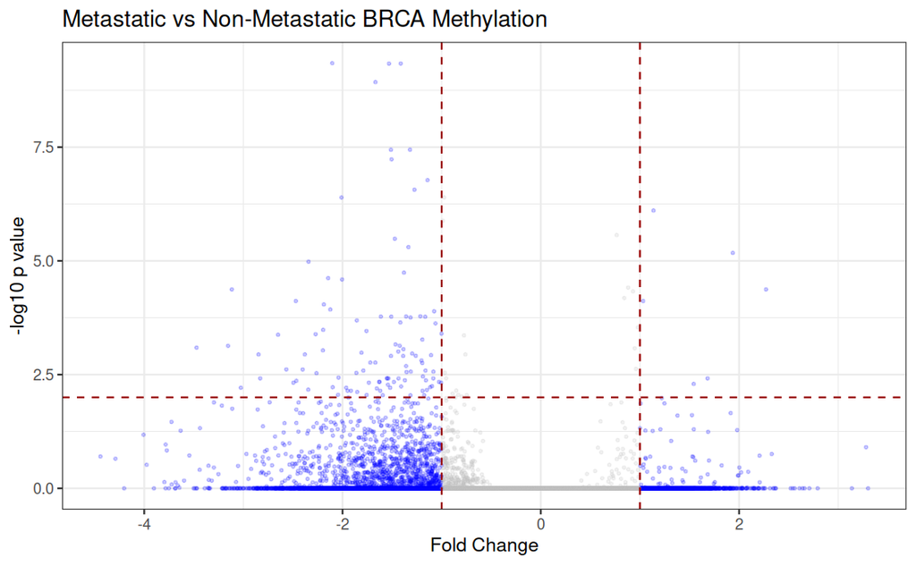

```r
# Extracting model into dataframe
dat <- data.frame(foldchange = fit[["coefficients"]][,2], logPvalue =  -log10(p.adjust(fit2[["p.value"]][,2],method='BY')), geneName = cpg_sites$gene)
dat$threshold <- as.factor(abs(dat$foldchange) < 1)

# Visualization
cols <- c("TRUE" = "grey", "FALSE" = "blue")
ggplot(data=dat, aes(x=foldchange, y = logPvalue, color = threshold)) +
  geom_point(alpha=.2, size=0.6) +
  scale_colour_manual(values = cols) +
  geom_vline(xintercept = 1, colour="#990000", linetype="dashed") +
  geom_vline(xintercept = - 1, colour="#990000", linetype="dashed") +
  geom_hline(yintercept = 2, colour = "#990000", linetype="dashed") +
  xlab("Fold Change") +
  ylab("-log10 p value") +
  ggtitle("Metastatic vs Non-Metastatic BRCA Methylation") +
  theme_bw() +
  theme(legend.position = "none")
```

```r
# Saving results to a .csv file
write.csv(dat, "methylation_results_metastatic.csv")
```

Many more CpG Sites are on left meaning negative fold change and little amount of points actually sit in the top-right box, meaning very few are actually significant. Only some site in general are actually significant with most being below the -log p value horizontlaly set. Overall, shows broad hypomethylation, but low statistical power is likely why it’s not significant enough to say anything for certain.